# 1. Import required libraries and read the dataset.

```python
import numpy as np
import pandas as pd
import seaborn as sns
import matplotlib.pyplot as plt
```

```python
data = pd.read_csv('honeyproduction.csv')
```

```python
data.head()
```

|  | state | numcol | yieldpercol | totalprod | stocks | priceperlb | prodvalue | year |
| --- | --- | --- | --- | --- | --- | --- | --- | --- |
| 0 | AL | 16000.0 | 71 | 1136000.0 | 159000.0 | 0.72 | 818000.0 | 1998 |
| 1 | AZ | 55000.0 | 60 | 3300000.0 | 1485000.0 | 0.64 | 2112000.0 | 1998 |
| 2 | AR | 53000.0 | 65 | 3445000.0 | 1688000.0 | 0.59 | 2033000.0 | 1998 |
| 3 | CA | 450000.0 | 83 | 37350000.0 | 12326000.0 | 0.62 | 23157000.0 | 1998 |
| 4 | CO | 27000.0 | 72 | 1944000.0 | 1594000.0 | 0.70 | 1361000.0 | 1998 |

```python
data.sample(4)
```

|  | state | numcol | yieldpercol | totalprod | stocks | priceperlb | prodvalue | year |
| --- | --- | --- | --- | --- | --- | --- | --- | --- |
| 467 | AZ | 20000.0 | 52 | 1040000.0 | 562000.0 | 1.45 | 1508000.0 | 2009 |
| 112 | NY | 58000.0 | 80 | 4640000.0 | 2274000.0 | 0.55 | 2552000.0 | 2000 |
| 241 | NJ | 10000.0 | 19 | 190000.0 | 101000.0 | 1.60 | 304000.0 | 2003 |
| 443 | MS | 14000.0 | 98 | 1372000.0 | 110000.0 | 1.30 | 1784000.0 | 2008 |

# 2. Check the first few samples, shape, info of the data and try to familiarize yourself with different features.

```python
data.info()
```

```
<class 'pandas.core.frame.DataFrame'>
RangeIndex: 626 entries, 0 to 625
Data columns (total 8 columns):
 #   Column       Non-Null Count  Dtype
---  ------       --------------  -----
 0   state        626 non-null    object
 1   numcol       626 non-null    float64
 2   yieldpercol  626 non-null    int64
 3   totalprod    626 non-null    float64
 4   stocks       626 non-null    float64
 5   priceperlb   626 non-null    float64
 6   prodvalue    626 non-null    float64
 7   year         626 non-null    int64
dtypes: float64(5), int64(2), object(1)
memory usage: 39.2+ KB
```

```python
data.shape
```

```
(626, 8)
```

```python
data.describe()
```

|  | numcol | yieldpercol | totalprod | stocks | priceperlb | prodvalue | year |
| --- | --- | --- | --- | --- | --- | --- | --- |
| count | 626.000000 | 626.000000 | 6.260000e+02 | 6.260000e+02 | 626.000000 | 6.260000e+02 | 626.000000 |
| mean | 60284.345048 | 62.009585 | 4.169086e+06 | 1.318859e+06 | 1.409569 | 4.715741e+06 | 2004.864217 |
| std | 91077.087231 | 19.458754 | 6.883847e+06 | 2.272964e+06 | 0.638599 | 7.976110e+06 | 4.317306 |
| min | 2000.000000 | 19.000000 | 8.400000e+04 | 8.000000e+03 | 0.490000 | 1.620000e+05 | 1998.000000 |
| 25% | 9000.000000 | 48.000000 | 4.750000e+05 | 1.430000e+05 | 0.932500 | 7.592500e+05 | 2001.000000 |
| 50% | 26000.000000 | 60.000000 | 1.533000e+06 | 4.395000e+05 | 1.360000 | 1.841500e+06 | 2005.000000 |
| 75% | 63750.000000 | 74.000000 | 4.175250e+06 | 1.489500e+06 | 1.680000 | 4.703250e+06 | 2009.000000 |
| max | 510000.000000 | 136.000000 | 4.641000e+07 | 1.380000e+07 | 4.150000 | 6.961500e+07 | 2012.000000 |

# 3. Display the percentage distribution of the data in each year using the pie chart.

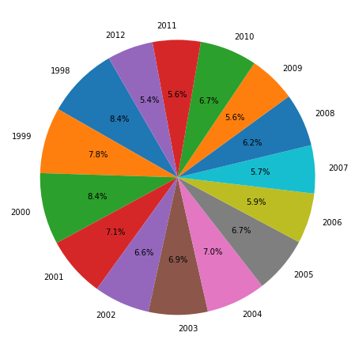

```python
distribution_interms_of_years = data.groupby("year")["totalprod"].sum()

plt.figure(figsize = (8,8))
plt.pie(distribution_interms_of_years,labels = distribution_interms_of_years.index, autopct='%1.1f%%', startangle = 120)
plt.show()
```

# 4. Plot and Understand the distribution of the variable "price per lb" using displot, and write your findings.

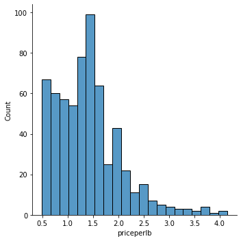

```python
sns.displot(data['priceperlb'])
```

The maximum count per data point ranges from 0 to 2.0, and the distribution is right-skewed, suggesting a higher prevalence of data points with lower counts and relatively fewer with higher counts. The average count per data point is computed to be 1.40.

# 5. Plot and understand the relationship between the variables 'numcol' and 'prodval' through scatterplot, and write your findings.

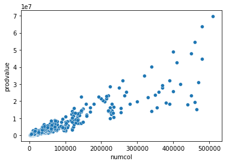

```python
sns.scatterplot(data = data, x='numcol', y='prodvalue')
```

# 6. Plot and understand the relationship between categorical variable 'year' and a numerical variable 'prodvalue' through boxplot, and write your findings.

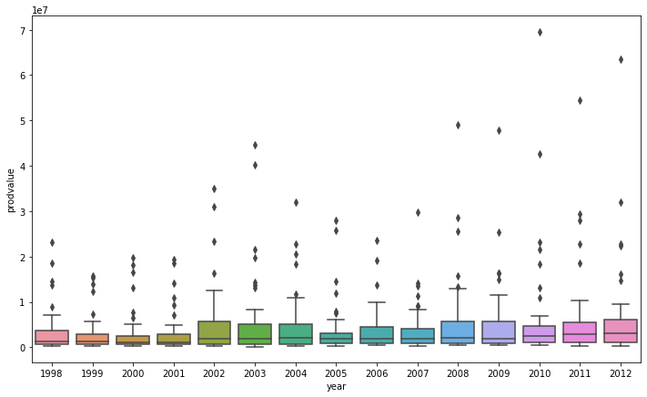

```python
plt.figure(figsize=(12,7))
sns.boxplot(data = data, x='year', y='prodvalue')
```

```python
GROUPED_data = data.groupby('year')['prodvalue'].describe()
GROUPED_data
```

| year | count | mean | std | min | 25% | 50% | 75% | max |
| --- | --- | --- | --- | --- | --- | --- | --- | --- |
| 1998 | 43.0 | 3.397465e+06 | 5.081114e+06 | 179000.0 | 645500.0 | 1361000.0 | 3746500.0 | 23157000.0 |
| 1999 | 43.0 | 2.875744e+06 | 4.068182e+06 | 186000.0 | 612500.0 | 1277000.0 | 2956000.0 | 15797000.0 |
| 2000 | 43.0 | 3.059721e+06 | 4.828234e+06 | 173000.0 | 580500.0 | 1035000.0 | 2559500.0 | 19665000.0 |
| 2001 | 44.0 | 3.006409e+06 | 4.581726e+06 | 174000.0 | 602000.0 | 1138500.0 | 2968750.0 | 19361000.0 |
| 2002 | 44.0 | 5.165955e+06 | 7.788900e+06 | 259000.0 | 731750.0 | 1836000.0 | 5613000.0 | 35040000.0 |
| 2003 | 44.0 | 5.729068e+06 | 9.591644e+06 | 162000.0 | 754500.0 | 1906500.0 | 5086000.0 | 44702000.0 |
| 2004 | 41.0 | 4.812366e+06 | 6.969411e+06 | 278000.0 | 716000.0 | 1984000.0 | 5052000.0 | 31941000.0 |
| 2005 | 41.0 | 3.921780e+06 | 6.091451e+06 | 345000.0 | 858000.0 | 1769000.0 | 2981000.0 | 27946000.0 |
| 2006 | 41.0 | 3.851805e+06 | 5.090348e+06 | 369000.0 | 785000.0 | 1826000.0 | 4554000.0 | 23569000.0 |
| 2007 | 41.0 | 3.935512e+06 | 5.481904e+06 | 309000.0 | 905000.0 | 1818000.0 | 4169000.0 | 29837000.0 |
| 2008 | 41.0 | 5.609561e+06 | 9.390274e+06 | 381000.0 | 946000.0 | 2016000.0 | 5775000.0 | 48960000.0 |
| 2009 | 40.0 | 5.348000e+06 | 8.793110e+06 | 474000.0 | 843750.0 | 1834500.0 | 5726750.0 | 47817000.0 |
| 2010 | 40.0 | 6.959250e+06 | 1.304975e+07 | 420000.0 | 1029000.0 | 2452000.0 | 4651250.0 | 69615000.0 |
| 2011 | 40.0 | 6.467200e+06 | 1.054978e+07 | 238000.0 | 1073000.0 | 2865500.0 | 5427250.0 | 54542000.0 |
| 2012 | 40.0 | 7.018125e+06 | 1.150000e+07 | 325000.0 | 1070750.0 | 3116000.0 | 6150750.0 | 63590000.0 |

The boxplots depict a decline in productivity between 1998 and 2001, followed by a notable upswing.

Throughout all observations, 50% of the production values are below 0.5 * 10^7.

# 7. Visualize and understand the relationship between the multiple pairs of variables throughout different years using pairplot and add your inferences. (use columns 'numcol', 'yield percol', 'total prod', 'prodvalue','year')

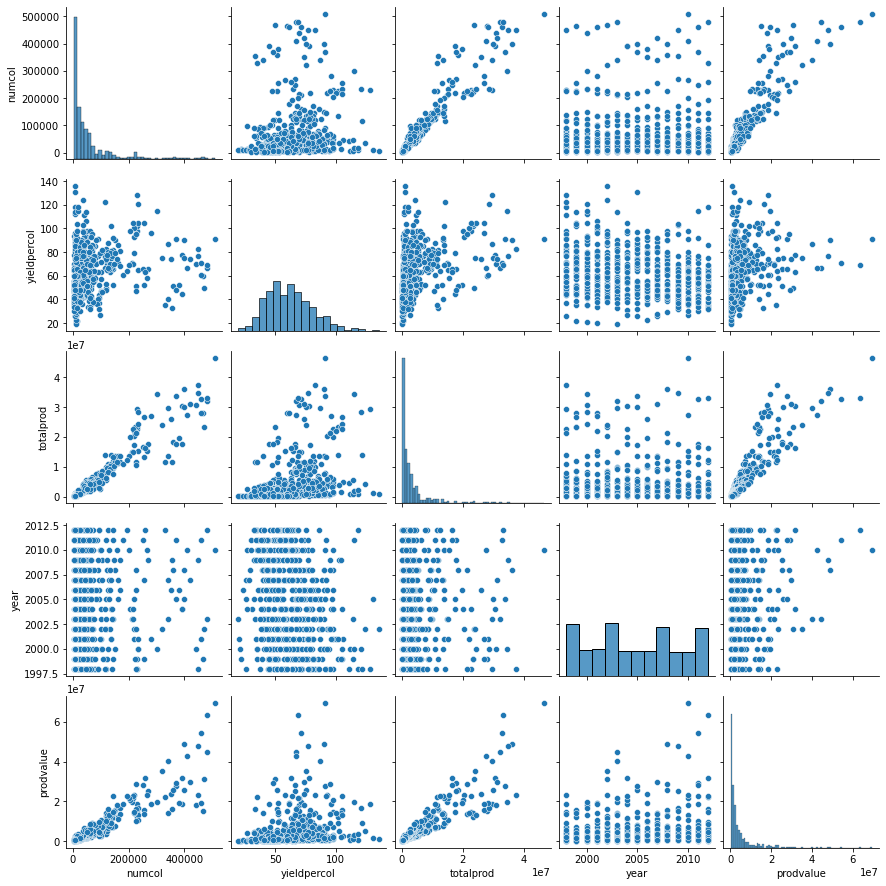

```python
sns.pairplot(data,vars=['numcol','yieldpercol','totalprod','year','prodvalue'])
```

numcol:

Histogram: Displaying positive skewness, the distribution is concentrated at the lower end, possibly exhibiting multimodality with a prominent peak and two smaller ones.

Scatter plot: The relationship between numcol and yieldpercol lacks meaningful patterns, as the data is clustered with several outliers.

A noteworthy positive linear correlation exists between numcol and totalprod, encompassing outliers.

numcol vs. prodvalue: Demonstrating a significant positive linear relationship with outliers, but showing less connection with totalprod.

There is no substantial correlation between the number of colonies and year, featuring numerous outliers.

yieldpercol:

Histogram: Centered concentration, potentially bimodal, with two prominent peaks and two smaller ones.

Scatter plot: yieldpercol vs. totalprod: Exhibiting a weak positive linear association, with the majority of data at the lower end of the totalprod scale.

yieldpercol vs. prodvalue: Showing a weak positive linear association, with the majority of data at the lower end of the prodvalue scale.

yieldpercol vs. year: Reflecting a negative linear association with dispersed data and numerous outliers.

totalprod:

Histogram: Concentrated near the bottom with a lengthy right-tailed distribution.

Scatter Plots totalprod vs. prodvalue: Displaying a strong positive linear relationship with a few exceptions.

Total production vs. year: Indicating a negative linear relationship with dispersed data and numerous outliers.

prodvalue:

Histogram: Concentrated near the bottom with a lengthy right-tailed distribution.

Scatter plot. Production value vs. year: Lacking a meaningful association, with numerous exceptions.

# 8. Display the correlation values using a plot and add your inferences. (use columns 'numcol', 'yield percol', 'total prod', 'stocks', 'price per lb', 'prodvalue')

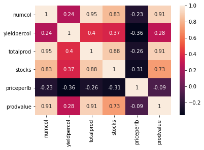

```python
selected_data=['numcol','yieldpercol','totalprod','stocks','priceperlb','prodvalue']
correlation = data[selected_data].corr()
sns.heatmap(correlation, annot=True)
```

Positive Correlation: A robust positive correlation is evident between the number of honey-producing colonies (numcol) and total honey production (totalprod), with a correlation coefficient of 0.953594. This indicates a significant tendency for total honey production to increase as the number of colonies rises. Similarly, there is a strong positive correlation between total honey production (totalprod) and honey stocks (stocks), reflected by a correlation coefficient of 0.878830. This suggests that higher total production is associated with elevated stocks of honey.

# PROJECT COMPLETED :)